# modelling_basic

# SEM basics

## What dataset to use, properties of data?

## Metamodel

[figure not shown]

## Load data

```r
rm(list = ls())
data <- read.table("~/Swiss_SEM/data_preparation/CedarCreek_Seabloom/seabloom-2020-ele-dryad-data/cdr-e001-e002-output-data.csv",
                       sep=",", header=TRUE)
```

## Explore data

Add overview of data.

## Subset to one year

First, we focus only of the data of one year.

```r
data <- data[data$year == 2000, ]
```

## Linear model

- visualisation as DAG
- residuals
- variance/covariance matrix

[figure not shown]

Split up into several lms.

```r
lm1 <- lm(mass.above ~ nadd + rich + even + disk,  data = data)
summary(lm1)
```

```
##
## Call:
## lm(formula = mass.above ~ nadd + rich + even + disk, data = data)
##
## Residuals:
##     Min      1Q  Median      3Q     Max
## -213.93  -59.75  -13.93   36.09  693.97
##
## Coefficients:
##             Estimate Std. Error t value Pr(>|t|)
## (Intercept)  68.9466    38.8773   1.773 0.077451 .
## nadd          6.7057     0.8348   8.033 4.59e-14 ***
## rich         12.7287     3.6515   3.486 0.000585 ***
## even         36.0762    40.5241   0.890 0.374248
## disk         12.3243    13.2333   0.931 0.352647
## ---
## Signif. codes:  0 '***' 0.001 '**' 0.01 '*' 0.05 '.' 0.1 ' ' 1
##
## Residual standard error: 100.4 on 235 degrees of freedom
## Multiple R-squared:  0.2182, Adjusted R-squared:  0.2048
## F-statistic: 16.39 on 4 and 235 DF,  p-value: 7.363e-12
```

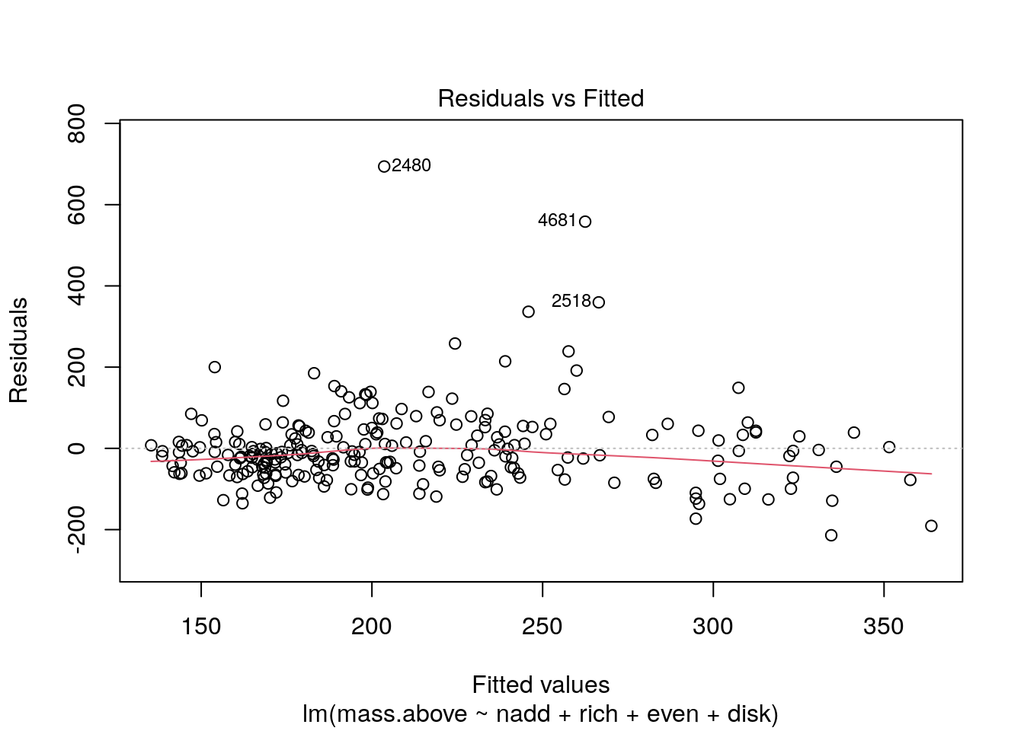

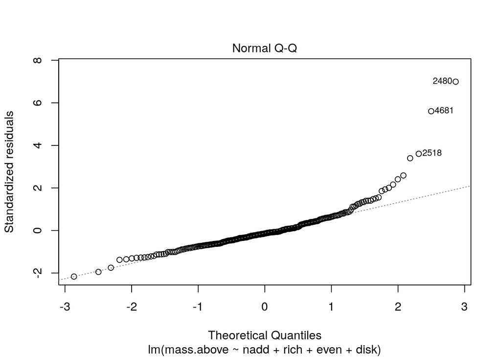

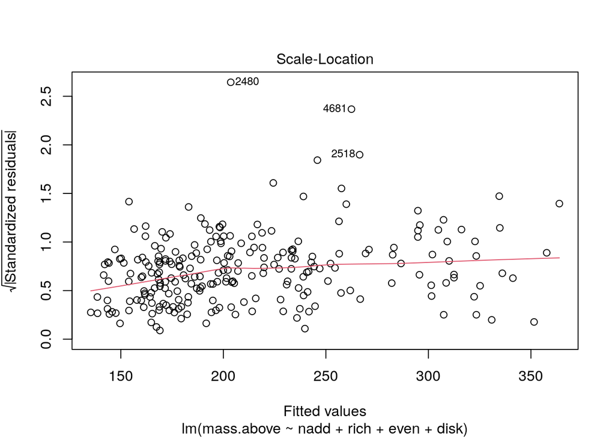

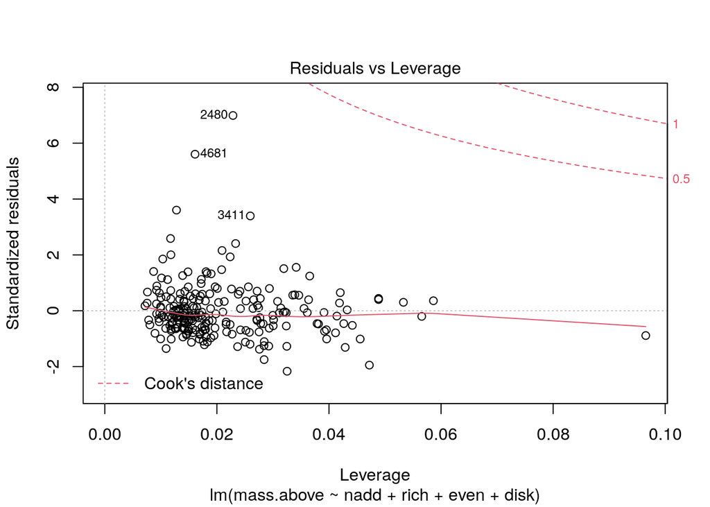

```r
plot(lm1)
```

## Simple SEM

This simple model shall illustrate the logic of SEM. Comparability is eased as it contains the same variables as the linear model before.

- visualisation as DAG
- explain model output
- assessment of fit

[figure not shown]

```r
library("lavaan")
sem1 <-
"mass.above ~ nadd + rich + even + disk
rich ~ nadd
even ~ nadd"

fit.sem1 <- sem(sem1, data = data)
```

### Scale variables

To reduce the difference in variances between the variables, we rescale them setting the mean to zero and the variance to one.

```r
data[, c(4, 7, 13:15)] <- apply(data[, c(4, 7, 13:15)], 2, scale)


fit.sem1 <- sem(sem1, data = data)
summary(fit.sem1, rsq = TRUE)
```

```
## lavaan 0.6-7 ended normally after 12 iterations
##
##   Estimator                                         ML
##   Optimization method                           NLMINB
##   Number of free parameters                          9
##
##   Number of observations                           240
##
## Model Test User Model:
##
##   Test statistic                               104.782
##   Degrees of freedom                                 3
##   P-value (Chi-square)                           0.000
##
## Parameter Estimates:
##
##   Standard errors                             Standard
##   Information                                 Expected
##   Information saturated (h1) model          Structured
##
## Regressions:
##                    Estimate  Std.Err  z-value  P(>|z|)
##   mass.above ~
##     nadd              0.529    0.065    8.161    0.000
##     rich              0.281    0.064    4.381    0.000
##     even              0.065    0.058    1.119    0.263
##     disk              0.054    0.057    0.941    0.346
##   rich ~
##     nadd             -0.459    0.057   -7.998    0.000
##   even ~
##     nadd              0.151    0.064    2.362    0.018
##
## Variances:
##                    Estimate  Std.Err  z-value  P(>|z|)
##    .mass.above        0.779    0.071   10.954    0.000
##    .rich              0.786    0.072   10.954    0.000
##    .even              0.973    0.089   10.954    0.000
##
## R-Square:
##                    Estimate
##     mass.above        0.233
##     rich              0.210
##     even              0.023
```

The model converged with poor fit:

- The ratio of the test statistic and the degrees of freedem should be **smaller than 2** (this ratio gives an indication how far away the model is from a decent fit)
- p-value should be larger than 0.05

### Modification indices

To improve the model we look for missing paths.

```r
modindices(fit.sem1, minimum.value = 3)
```

```
##     lhs op        rhs     mi    epc sepc.lv sepc.all sepc.nox
## 15 rich ~~       even 84.811 -0.520  -0.520   -0.594   -0.594
## 16 rich  ~ mass.above 51.301 -4.922  -4.922   -4.969   -4.969
## 17 rich  ~       even 84.811 -0.534  -0.534   -0.534   -0.534
## 19 even  ~ mass.above 79.659 -2.227  -2.227   -2.248   -2.248
## 20 even  ~       rich 84.811 -0.661  -0.661   -0.661   -0.661
```

In the column `mi` (modification index) we look for high values… Highest values are between `rich` and `even` and therefore, we include a correlation between them.

```r
fit.sem1.up <- update(fit.sem1, add = "rich ~~ even")
summary(fit.sem1.up, rsq = TRUE, fit.measures=T)
```

```
## lavaan 0.6-7 ended normally after 18 iterations
##
##   Estimator                                         ML
##   Optimization method                           NLMINB
##   Number of free parameters                         10
##
##   Number of observations                           240
##
## Model Test User Model:
##
##   Test statistic                                 0.143
##   Degrees of freedom                                 2
##   P-value (Chi-square)                           0.931
##
## Model Test Baseline Model:
##
##   Test statistic                               226.074
##   Degrees of freedom                                 9
##   P-value                                        0.000
##
## User Model versus Baseline Model:
##
##   Comparative Fit Index (CFI)                    1.000
##   Tucker-Lewis Index (TLI)                       1.039
##
## Loglikelihood and Information Criteria:
##
##   Loglikelihood user model (H0)               -907.167
##   Loglikelihood unrestricted model (H1)       -907.096
##
##   Akaike (AIC)                                1834.334
##   Bayesian (BIC)                              1869.141
##   Sample-size adjusted Bayesian (BIC)         1837.443
##
## Root Mean Square Error of Approximation:
##
##   RMSEA                                          0.000
##   90 Percent confidence interval - lower         0.000
##   90 Percent confidence interval - upper         0.037
##   P-value RMSEA <= 0.05                          0.961
```

[output cut: 24 more lines]

```
##                    Estimate  Std.Err  z-value  P(>|z|)
##  .rich ~~
##    .even             -0.520    0.066   -7.916    0.000
##
## Variances:
##                    Estimate  Std.Err  z-value  P(>|z|)
##    .mass.above        0.779    0.071   10.954    0.000
##    .rich              0.786    0.072   10.954    0.000
##    .even              0.973    0.089   10.954    0.000
##
## R-Square:
##                    Estimate
##     mass.above        0.218
##     rich              0.210
##     even              0.023
```

```r
# standardizedsolution(fit.sem1.up)
# inspect(fit.sem1.up, "r2")
```

### Plot the model

```r
library(lavaanPlot)

lavaanPlot(model = fit.sem1.up, node_options = list(shape = "box",
                                                    fontname = "Helvetica"),
           edge_options = list(color = "grey"), coefs = TRUE, stand = FALSE,
           sig = 0.05)
```

[interactive chart not shown]

### Random terms with piecewiseSEM

We can do the same in piecewiseSEM. The advantage is that we can include some random structure in the model. Let’s take a look first at the model without random terms.

```r
library(piecewiseSEM)
library(nlme)

Psem1List <- list(
  lm(mass.above ~ rich + even + nadd + disk, data),
  lm(rich ~ nadd, data),
  lm(even ~ nadd, data),
  even %~~% rich
)


Psem1 <- as.psem(Psem1List)
summary(Psem1, .progressBar = F)
```

```
##
## Structural Equation Model of Psem1
##
## Call:
##   mass.above ~ rich + even + nadd + disk
##   rich ~ nadd
##   even ~ nadd
##   even ~~ rich
##
##     AIC      BIC
##  24.988   66.756
##
## ---
## Tests of directed separation:
##
##      Independ.Claim Test.Type  DF Crit.Value P.Value
##   rich ~ disk + ...      coef 237    -0.1780  0.8589
##   even ~ disk + ...      coef 237     0.3717  0.7104
##
## Global goodness-of-fit:
##
##   Fisher's C = 0.988 with P-value = 0.912 and on 4 degrees of freedom
##
## ---
## Coefficients:
##
##     Response Predictor Estimate Std.Error  DF Crit.Value P.Value Std.Estimate
##   mass.above      rich   0.2814    0.0807 235     3.4859  0.0006       0.2814
##   mass.above      even   0.0646    0.0726 235     0.8902  0.3742       0.0646
##   mass.above      nadd   0.5290    0.0659 235     8.0330  0.0000       0.5290
##   mass.above      disk   0.0537    0.0577 235     0.9313  0.3526       0.0537
##         rich      nadd  -0.4588    0.0576 238    -7.9648  0.0000      -0.4588
##         even      nadd   0.1507    0.0641 238     2.3525  0.0195       0.1507
##       ~~even    ~~rich  -0.5945         - 240   -11.3808  0.0000      -0.5945
##
##   ***
##
##   ***
##
##   ***
##     *
##   ***
##
##   Signif. codes:  0 '***' 0.001 '**' 0.01 '*' 0.05
##
## ---
## Individual R-squared:
##
##     Response method R.squared
##   mass.above   none      0.22
##         rich   none      0.21
##         even   none      0.02
```

We see that the model fit is good (because we included the correlation between richness and evenness’ errors). The data was collected in plots within fields, which adds a block effect to our structure. Let’s try out with the random term.

```r
Psem1RandomList <- list(
  lme(mass.above ~ rich + even + nadd + disk, random = ~ 1|field, data),
  lme(rich ~ nadd, random = ~ 1|field, data),
  lme(even ~ nadd, random = ~ 1|field, data),
  even %~~% rich
)


Psem1Random <- as.psem(Psem1RandomList)
summary(Psem1Random, .progressBar = F)
```

```
##
## Structural Equation Model of Psem1Random
##
## Call:
##   mass.above ~ rich + even + nadd + disk
##   rich ~ nadd
##   even ~ nadd
##   even ~~ rich
##
##     AIC      BIC
##  31.728   83.938
##
## ---
## Tests of directed separation:
##
##      Independ.Claim Test.Type  DF Crit.Value P.Value
##   rich ~ disk + ...      coef 235     0.7858  0.4328
##   even ~ disk + ...      coef 235    -0.0327  0.9739
##
## Global goodness-of-fit:
##
##   Fisher's C = 1.728 with P-value = 0.786 and on 4 degrees of freedom
##
## ---
## Coefficients:
##
##     Response Predictor Estimate Std.Error  DF Crit.Value P.Value Std.Estimate
##   mass.above      rich   0.0625    0.0977 233     0.6391  0.5234       0.0625
##   mass.above      even  -0.0144    0.0733 233    -0.1972  0.8439      -0.0144
##   mass.above      nadd   0.4405    0.0682 233     6.4587  0.0000       0.4405
##   mass.above      disk   0.0640    0.0567 233     1.1281  0.2604       0.0640
##         rich      nadd  -0.4588    0.0463 236    -9.9084  0.0000      -0.4588
##         even      nadd   0.1507    0.0628 236     2.3987  0.0172       0.1507
##       ~~even    ~~rich  -0.6174         - 240   -12.0818  0.0000      -0.6174
##
##
##
##   ***
##
##   ***
##     *
##   ***
##
##   Signif. codes:  0 '***' 0.001 '**' 0.01 '*' 0.05
##
## ---
## Individual R-squared:
##
##     Response method Marginal Conditional
##   mass.above   none     0.17        0.29
##         rich   none     0.18        0.56
##         even   none     0.02        0.08
```

We see here that the richness effect on biomass became non-significant.

### Simple model: Random terms with lavaan

```r
# modfit<-sem(model, data=dat, estimator = "mlm")
# survey.design <- svydesign(ids=~1, strata = ~ spatial_block, prob =~1, data=dat)
# fit_with_blocks <- lavaan.survey(modfit, survey.design)
# summary(fit_with_blocks, rsquare=T, standardized = T, fit.measures = T)


library(survey)
library(lavaan.survey)

modfit <- sem(model = fit.sem1.up, data = data, estimator = "mlm")
survey.design <- svydesign(ids = ~1, strata = ~ field, prob = ~1, data = data)
# fit_with_blocks <- lavaan.survey(modfit, survey.design)
# summary(fit_with_blocks, rsquare = TRUE, standardized = TRUE,
#         fit.measures = TRUE)
```

## Saturated model

[figure not shown]

```r
sem2 <-
"mass.above ~ nadd + rich + even + disk
rich ~ nadd + disk
even ~ nadd + disk

rich ~~ even"

fit.sem2 <- sem(sem2, data = data)
summary(fit.sem2, rsq = TRUE)
```

```
## lavaan 0.6-7 ended normally after 18 iterations
##
##   Estimator                                         ML
##   Optimization method                           NLMINB
##   Number of free parameters                         12
##
##   Number of observations                           240
##
## Model Test User Model:
##
##   Test statistic                                 0.000
##   Degrees of freedom                                 0
##
## Parameter Estimates:
##
##   Standard errors                             Standard
##   Information                                 Expected
##   Information saturated (h1) model          Structured
##
## Regressions:
##                    Estimate  Std.Err  z-value  P(>|z|)
##   mass.above ~
##     nadd              0.529    0.065    8.118    0.000
##     rich              0.281    0.080    3.523    0.000
##     even              0.065    0.072    0.900    0.368
##     disk              0.054    0.057    0.941    0.347
##   rich ~
##     nadd             -0.459    0.057   -7.999    0.000
##     disk             -0.010    0.057   -0.179    0.858
##   even ~
##     nadd              0.151    0.064    2.363    0.018
##     disk              0.024    0.064    0.374    0.708
##
## Covariances:
##                    Estimate  Std.Err  z-value  P(>|z|)
##  .rich ~~
##    .even             -0.520    0.066   -7.916    0.000
##
## Variances:
##                    Estimate  Std.Err  z-value  P(>|z|)
##    .mass.above        0.779    0.071   10.954    0.000
##    .rich              0.786    0.072   10.954    0.000
##    .even              0.973    0.089   10.954    0.000
##
## R-Square:
##                    Estimate
##     mass.above        0.218
##     rich              0.211
##     even              0.023
```

Let’s have another look at the modification indices.

```r
modindices(fit.sem2, minimum.value = 3)
```

```
## [1] lhs      op       rhs      mi       epc      sepc.lv  sepc.all sepc.nox
## <0 rows> (or 0-length row.names)
```

The modification indices shows that the model is saturated and thus, no further paths can be added to improve the model fit.

### Random terms with piecewiseSEM

Let’s try again to add the random structure and compare lavaan and piecewise outputs.

```r
Psem2RandomList <- list(
  lme(mass.above ~ rich + even + nadd + disk, random = ~ 1|field, data),
  lme(rich ~ nadd + disk, random = ~ 1|field, data),
  lme(even ~ nadd + disk, random = ~ 1|field, data),
  even %~~% rich
)

Psem2Random <- as.psem(Psem2RandomList)
summary(Psem2Random, .progressBar = F)
```

```
##
## Structural Equation Model of Psem2Random
##
## Call:
##   mass.above ~ rich + even + nadd + disk
##   rich ~ nadd + disk
##   even ~ nadd + disk
##   even ~~ rich
##
##     AIC      BIC
##  34.000   93.171
##
## ---
## Tests of directed separation:
##
##  No independence claims present. Tests of directed separation not possible.
##
## Global goodness-of-fit:
##
##   Fisher's C = 0 with P-value = 1 and on 0 degrees of freedom
##
## ---
## Coefficients:
##
##     Response Predictor Estimate Std.Error  DF Crit.Value P.Value Std.Estimate
##   mass.above      rich   0.0625    0.0977 233     0.6391  0.5234       0.0625
##   mass.above      even  -0.0144    0.0733 233    -0.1972  0.8439      -0.0144
##   mass.above      nadd   0.4405    0.0682 233     6.4587  0.0000       0.4405
##   mass.above      disk   0.0640    0.0567 233     1.1281  0.2604       0.0640
##         rich      nadd  -0.4588    0.0463 235    -9.9009  0.0000      -0.4588
##         rich      disk   0.0369     0.047 235     0.7858  0.4328       0.0369
##         even      nadd   0.1507     0.063 235     2.3936  0.0175       0.1507
##         even      disk  -0.0021    0.0637 235    -0.0327  0.9739      -0.0021
##       ~~even    ~~rich  -0.6178         - 240   -12.0962  0.0000      -0.6178
##
##
##
##   ***
##
##   ***
##
##     *
##
##   ***
##
##   Signif. codes:  0 '***' 0.001 '**' 0.01 '*' 0.05
##
## ---
## Individual R-squared:
##
##     Response method Marginal Conditional
##   mass.above   none     0.17        0.29
##         rich   none     0.18        0.56
##         even   none     0.02        0.08
```

### Model pruning

Now, let’s delete all non-significant paths from the model.

```r
sem.prune <-
"mass.above ~ nadd + rich
rich ~ nadd
even ~ nadd

rich ~~ even"

fit.sem.prune <- sem(sem.prune, data = data)
summary(fit.sem.prune)
```

```
## lavaan 0.6-7 ended normally after 18 iterations
##
##   Estimator                                         ML
##   Optimization method                           NLMINB
##   Number of free parameters                          9
##
##   Number of observations                           240
##
## Model Test User Model:
##
##   Test statistic                                 0.000
##   Degrees of freedom                                 0
##
## Parameter Estimates:
##
##   Standard errors                             Standard
##   Information                                 Expected
##   Information saturated (h1) model          Structured
##
## Regressions:
##                    Estimate  Std.Err  z-value  P(>|z|)
##   mass.above ~
##     nadd              0.519    0.064    8.048    0.000
##     rich              0.238    0.064    3.691    0.000
##   rich ~
##     nadd             -0.459    0.057   -7.998    0.000
##   even ~
##     nadd              0.151    0.064    2.362    0.018
##
## Covariances:
##                    Estimate  Std.Err  z-value  P(>|z|)
##  .rich ~~
##    .even             -0.520    0.066   -7.916    0.000
##  .mass.above ~~
##    .even              0.042    0.045    0.915    0.360
##
## Variances:
##                    Estimate  Std.Err  z-value  P(>|z|)
##    .mass.above        0.784    0.072   10.954    0.000
##    .rich              0.786    0.072   10.954    0.000
##    .even              0.973    0.089   10.954    0.000
```

## Model comparison

- add an additional variable or path, then compare the two SEMs

## SEM with latent and composite variables

- difference between latent and composite variable
- SEM with latent variable(s)
- SEM with composite variable(s)

[figure not shown]

# SEM with latent variable “diversity”

```r
sem2 <-"
# Latent variable definition
diversity =~ rich + even

mass.above ~ nadd + diversity + disk
diversity ~ nadd
"

fit.sem2 <- sem(sem2, data = data)
summary(fit.sem2)
```

```
## lavaan 0.6-7 ended normally after 25 iterations
##
##   Estimator                                         ML
##   Optimization method                           NLMINB
##   Number of free parameters                          9
##
##   Number of observations                           240
##
## Model Test User Model:
##
##   Test statistic                                 0.305
##   Degrees of freedom                                 3
##   P-value (Chi-square)                           0.959
##
## Parameter Estimates:
##
##   Standard errors                             Standard
##   Information                                 Expected
##   Information saturated (h1) model          Structured
##
## Latent Variables:
##                    Estimate  Std.Err  z-value  P(>|z|)
##   diversity =~
##     rich              1.000
##     even             -0.348    0.108   -3.216    0.001
##
## Regressions:
##                    Estimate  Std.Err  z-value  P(>|z|)
##   mass.above ~
##     nadd              0.466    0.064    7.339    0.000
##     diversity         0.122    0.055    2.242    0.025
##     disk              0.053    0.057    0.933    0.351
##   diversity ~
##     nadd             -0.462    0.057   -8.133    0.000
##
## Variances:
##                    Estimate  Std.Err  z-value  P(>|z|)
##    .rich             -0.698    0.470   -1.485    0.138
##    .even              0.791    0.092    8.640    0.000
##    .mass.above        0.804    0.073   11.037    0.000
##    .diversity         1.482    0.482    3.075    0.002
```

# SEM with composite variable “land use intensity”

## SEM with interaction

[figure not shown]

## SEM with autocorrelation (temporal, spatial) –> advanced?